# Investigation into Vehicle Insurance Claims Fraud

Authors : Killian Hughes, Lauren Gorst, Peter Scaife, Taslima Hossain 08/01/2024

Overview

This reports seeks to investigate vehicle claims in the United States of America, specifically the fraud tendancy of different profiles' claims insurance policies. The report will proceed in the following way: data is extracted in its raw form from the csv file 'insurance_claims.csv' taken from the Mendeley data website, then the data will be cleaned for the purpose of processing for data visualisations and further machine learning models to aid early predictive fraud detection.

Data Source : insurace_claims.csv

The Purpose of this report is esential to aid insurance companies in the early detection of vehicle insurance fraud based on historical data. Data visualistions will insure an accurate overview of current trends in this domain.

### Report Contents

- Section 1 : Data Overview
- Section 2 : Data Cleaning
- Section 3 : Data Visualisations
- Section 4 : Evaluations and Further Insights
- Section 5 : Conclusion

### Section 1 : Data Overview

The data is first imported using Pandas to perform an initial investigation. Below are the imports necessary for the report.

```python
# Imports

import pandas as pd
import matplotlib.pyplot as plt
import seaborn as sns
import numpy as np
```

```python
df = pd.read_csv("insurance_claims.csv")
display(df)
```

|  | months_as_customer | age | policy_number | policy_bind_date | policy_state | policy_csl | policy_deductable | policy_annual_premium | umbrella_limit | insured_zip | ... | police_report_available | total_claim_amount | injury_claim | property_claim | vehicle_claim | auto_make | auto_model | auto_year | fraud_reported | _c39 |
| --- | --- | --- | --- | --- | --- | --- | --- | --- | --- | --- | --- | --- | --- | --- | --- | --- | --- | --- | --- | --- | --- |
| 0 | 328 | 48 | 521585 | 2014-10-17 | OH | 250/500 | 1000 | 1406.91 | 0 | 466132 | ... | YES | 71610 | 6510 | 13020 | 52080 | Saab | 92x | 2004 | Y | NaN |
| 1 | 228 | 42 | 342868 | 2006-06-27 | IN | 250/500 | 2000 | 1197.22 | 5000000 | 468176 | ... | ? | 5070 | 780 | 780 | 3510 | Mercedes | E400 | 2007 | Y | NaN |
| 2 | 134 | 29 | 687698 | 2000-09-06 | OH | 100/300 | 2000 | 1413.14 | 5000000 | 430632 | ... | NO | 34650 | 7700 | 3850 | 23100 | Dodge | RAM | 2007 | N | NaN |
| 3 | 256 | 41 | 227811 | 1990-05-25 | IL | 250/500 | 2000 | 1415.74 | 6000000 | 608117 | ... | NO | 63400 | 6340 | 6340 | 50720 | Chevrolet | Tahoe | 2014 | Y | NaN |
| 4 | 228 | 44 | 367455 | 2014-06-06 | IL | 500/1000 | 1000 | 1583.91 | 6000000 | 610706 | ... | NO | 6500 | 1300 | 650 | 4550 | Accura | RSX | 2009 | N | NaN |
| ... | ... | ... | ... | ... | ... | ... | ... | ... | ... | ... | ... | ... | ... | ... | ... | ... | ... | ... | ... | ... | ... |
| 995 | 3 | 38 | 941851 | 1991-07-16 | OH | 500/1000 | 1000 | 1310.80 | 0 | 431289 | ... | ? | 87200 | 17440 | 8720 | 61040 | Honda | Accord | 2006 | N | NaN |
| 996 | 285 | 41 | 186934 | 2014-01-05 | IL | 100/300 | 1000 | 1436.79 | 0 | 608177 | ... | ? | 108480 | 18080 | 18080 | 72320 | Volkswagen | Passat | 2015 | N | NaN |
| 997 | 130 | 34 | 918516 | 2003-02-17 | OH | 250/500 | 500 | 1383.49 | 3000000 | 442797 | ... | YES | 67500 | 7500 | 7500 | 52500 | Suburu | Impreza | 1996 | N | NaN |
| 998 | 458 | 62 | 533940 | 2011-11-18 | IL | 500/1000 | 2000 | 1356.92 | 5000000 | 441714 | ... | YES | 46980 | 5220 | 5220 | 36540 | Audi | A5 | 1998 | N | NaN |
| 999 | 456 | 60 | 556080 | 1996-11-11 | OH | 250/500 | 1000 | 766.19 | 0 | 612260 | ... | ? | 5060 | 460 | 920 | 3680 | Mercedes | E400 | 2007 | N | NaN |

1000 rows × 40 columns

The data includes 1000 rows and 40 columns. For the purpose of the investgation we have decided to limit the number of columns choosing to omit columns: Umbrella_limit, insured_relationship, Property_damage, _c39. Namely c_39 represented a completely void column with no description.

We can also note that our data relates to three policy states in particular: Illinois, Ohio, Indiana.

```python
missing_values = df.isnull().sum()
missing_values
```

```
months_as_customer                0
age                               0
policy_number                     0
policy_bind_date                  0
policy_state                      0
policy_csl                        0
policy_deductable                 0
policy_annual_premium             0
umbrella_limit                    0
insured_zip                       0
insured_sex                       0
insured_education_level           0
insured_occupation                0
insured_hobbies                   0
insured_relationship              0
capital-gains                     0
capital-loss                      0
incident_date                     0
incident_type                     0
collision_type                    0
incident_severity                 0
authorities_contacted            91
incident_state                    0
incident_city                     0
incident_location                 0
incident_hour_of_the_day          0
number_of_vehicles_involved       0
property_damage                   0
bodily_injuries                   0
witnesses                         0
police_report_available           0
total_claim_amount                0
injury_claim                      0
property_claim                    0
vehicle_claim                     0
auto_make                         0
auto_model                        0
auto_year                         0
fraud_reported                    0
_c39                           1000
dtype: int64
```

This technique of detecting null values demonstrates an incorrect logical assumption that all missing values are already labelled as null values in the dataframe. Note that for the column 'authorities_contacted' the value 'None' is considered a null value despite importantly signifying that no authority was contacted.

Upon closer inspection of the data frame we can observe that the character '?' is used as a place holder for a null value in all affected columns and represents no further insights within the data set.

```python
place_holder = df[df=='?'].count()
place_holder
```

```
months_as_customer               0
age                              0
policy_number                    0
policy_bind_date                 0
policy_state                     0
policy_csl                       0
policy_deductable                0
policy_annual_premium            0
umbrella_limit                   0
insured_zip                      0
insured_sex                      0
insured_education_level          0
insured_occupation               0
insured_hobbies                  0
insured_relationship             0
capital-gains                    0
capital-loss                     0
incident_date                    0
incident_type                    0
collision_type                 178
incident_severity                0
authorities_contacted            0
incident_state                   0
incident_city                    0
incident_location                0
incident_hour_of_the_day         0
number_of_vehicles_involved      0
property_damage                360
bodily_injuries                  0
witnesses                        0
police_report_available        343
total_claim_amount               0
injury_claim                     0
property_claim                   0
vehicle_claim                    0
auto_make                        0
auto_model                       0
auto_year                        0
fraud_reported                   0
_c39                             0
dtype: int64
```

To visually describe the scale of our missing values, we will first replace all placeholder characters with nulls and use a heatmap to observe our findings for each column of the data frame.

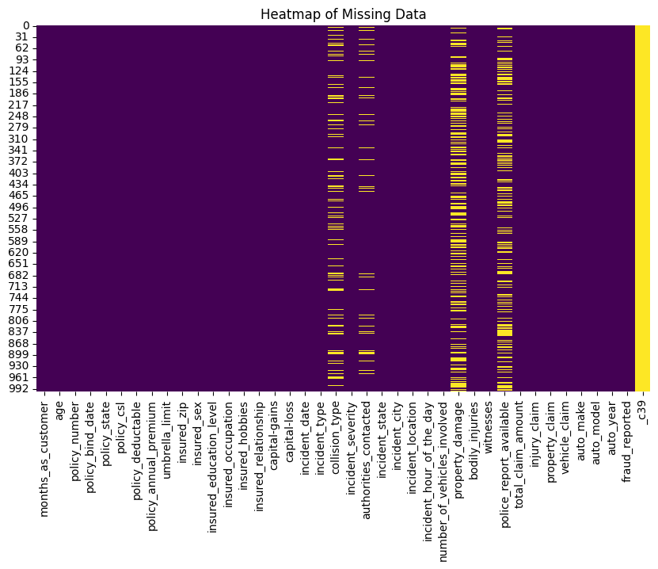

```python
replaced_var = df.replace('?', np.NaN)

def is_null_data_heat(df):
    df.replace('Varies with device', np.nan, inplace=True)
    plt.figure(figsize=(10, 6))
    sns.heatmap(df.isnull(), cmap='viridis', cbar=False)
    plt.title('Heatmap of Missing Data')
    plt.show()

is_null_data_heat(replaced_var)
```

### Section 2: Data Cleaning

Initial aims of data cleaning:

- Removal of duplicates
- Identifying missing values
- Ensuring uniform formatting
- Identifying outliers

The following remove the columns judged as being not of interest to the report.

```python
columns_to_remove = ['umbrella_limit', 'insured_relationship', 'property_damage', '_c39']
df = df.drop(columns=columns_to_remove)
```

The following will give an overview of the data points within the data frame.

```python
for column in df.columns:
    unique_strings_overview = df[column].value_counts()
    print(f"\nOverview for {column}:")
    print(unique_strings_overview)
```

```
Overview for months_as_customer:
months_as_customer
194    8
128    7
254    7
140    7
210    7
      ..
390    1
411    1
453    1
448    1
17     1
Name: count, Length: 391, dtype: int64

Overview for age:
age
43    49
39    48
41    45
34    44
38    42
30    42
31    42
37    41
33    39
40    38
32    38
29    35
46    33
42    32
35    32
36    32
44    32
28    30
26    26
45    26
48    25
47    24
27    24
```

[output cut: 522 more lines]

```
2012    46
2008    45
2014    44
2001    42
2000    42
1998    40
2004    39
1996    37
Name: count, dtype: int64

Overview for fraud_reported:
fraud_reported
N    753
Y    247
Name: count, dtype: int64
```

Once identifiied the character '?' is officially replaced within the cleaned data frame by the null value representation 'NA'.

```python
df.replace('?', pd.NA, inplace=True)
```

The following is the subsequent heat map.

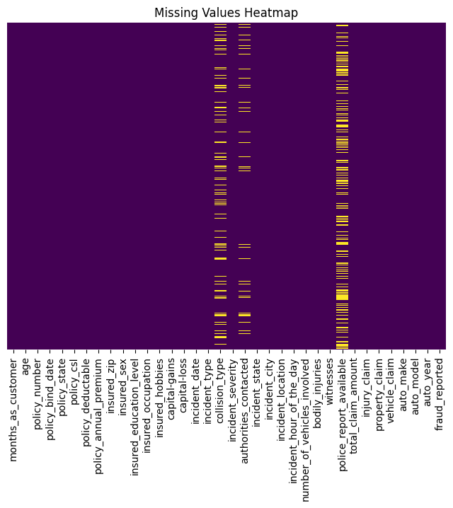

```python
plt.figure(figsize=(8, 6))
sns.heatmap(df.isnull(), cmap='viridis', cbar=False, yticklabels=False)
plt.title('Missing Values Heatmap')
plt.show()
```

To check for duplicates the following code is used to sum all duplicated rows in the data frame.

```python
df.duplicated().sum()
```

```
0
```

The next code removes the primary key (which should all be individual values), to check for further duplicates

```python
df.duplicated(subset=df.columns.difference(['policy_number']), keep=False).sum()
```

```
0
```

In order to identifying outliers we first found the interquartile range, upper bound and lower bound. Data points considred outside of this bounded range were treated as outliers.

```python
def detect_outliers_iqr(column):
    q1 = column.quantile(0.25)
    q3 = column.quantile(0.75)
    iqr = q3 - q1
    lower_bound = q1 - 1.5 * iqr
    upper_bound = q3 + 1.5 * iqr
    outliers = (column < lower_bound) | (column > upper_bound)
    return outliers
```

```python
outliers_column1 = detect_outliers_iqr(df['months_as_customer'])
outliers_column1.sum()
```

```
0
```

```python
outliers_column2 = detect_outliers_iqr(df['age'])
outliers_column2.sum()
df[outliers_column2]
```

|  | months_as_customer | age | policy_number | policy_bind_date | policy_state | policy_csl | policy_deductable | policy_annual_premium | insured_zip | insured_sex | ... | witnesses | police_report_available | total_claim_amount | injury_claim | property_claim | vehicle_claim | auto_make | auto_model | auto_year | fraud_reported |
| --- | --- | --- | --- | --- | --- | --- | --- | --- | --- | --- | --- | --- | --- | --- | --- | --- | --- | --- | --- | --- | --- |
| 67 | 478 | 64 | 346002 | 1990-08-20 | OH | 250/500 | 500 | 835.02 | 602433 | FEMALE | ... | 1 | NO | 33930 | 0 | 3770 | 30160 | BMW | X6 | 1998 | N |
| 538 | 478 | 63 | 852002 | 2009-06-29 | IL | 250/500 | 1000 | 1292.30 | 479724 | MALE | ... | 3 | NO | 4700 | 940 | 470 | 3290 | Dodge | Neon | 2007 | Y |
| 588 | 472 | 64 | 911429 | 2012-08-25 | IN | 250/500 | 500 | 989.24 | 615821 | MALE | ... | 3 | NO | 70900 | 14180 | 7090 | 49630 | Mercedes | ML350 | 2002 | N |
| 947 | 465 | 63 | 531160 | 2012-01-12 | IL | 250/500 | 500 | 1006.99 | 458936 | FEMALE | ... | 3 | <NA> | 43560 | 4840 | 4840 | 33880 | Suburu | Legacy | 2015 | N |

4 rows × 36 columns

```python
outliers_column3 = detect_outliers_iqr(df['policy_deductable'])
outliers_column3.sum()
```

```
0
```

```python
outliers_column4 = detect_outliers_iqr(df['policy_annual_premium'])
outliers_column4
df[outliers_column4]
```

|  | months_as_customer | age | policy_number | policy_bind_date | policy_state | policy_csl | policy_deductable | policy_annual_premium | insured_zip | insured_sex | ... | witnesses | police_report_available | total_claim_amount | injury_claim | property_claim | vehicle_claim | auto_make | auto_model | auto_year | fraud_reported |
| --- | --- | --- | --- | --- | --- | --- | --- | --- | --- | --- | --- | --- | --- | --- | --- | --- | --- | --- | --- | --- | --- |
| 43 | 106 | 30 | 790442 | 2003-04-13 | OH | 250/500 | 500 | 538.17 | 433782 | FEMALE | ... | 2 | NO | 51120 | 5680 | 5680 | 39760 | Mercedes | E400 | 2005 | N |
| 133 | 24 | 33 | 649082 | 1996-01-19 | IL | 500/1000 | 1000 | 1922.84 | 431277 | FEMALE | ... | 1 | NO | 46800 | 4680 | 9360 | 32760 | Jeep | Wrangler | 2002 | N |
| 229 | 154 | 37 | 241562 | 2010-01-28 | IL | 250/500 | 1000 | 2047.59 | 439269 | FEMALE | ... | 3 | NO | 79530 | 14460 | 7230 | 57840 | Accura | MDX | 2000 | N |
| 248 | 101 | 27 | 326322 | 2007-02-10 | IL | 250/500 | 1000 | 433.33 | 603269 | MALE | ... | 3 | NO | 5900 | 1180 | 590 | 4130 | Mercedes | E400 | 2009 | N |
| 544 | 254 | 40 | 349658 | 1994-06-07 | IN | 100/300 | 500 | 1927.87 | 609317 | MALE | ... | 1 | <NA> | 43280 | 0 | 5410 | 37870 | Honda | Civic | 1996 | Y |
| 681 | 32 | 38 | 719989 | 1994-04-07 | IL | 250/500 | 2000 | 566.11 | 453164 | MALE | ... | 0 | NO | 2640 | 440 | 440 | 1760 | Honda | CRV | 2015 | N |
| 747 | 37 | 31 | 230223 | 2008-09-06 | IL | 500/1000 | 500 | 1969.63 | 615218 | FEMALE | ... | 1 | YES | 76450 | 6950 | 13900 | 55600 | Dodge | RAM | 1995 | N |
| 763 | 66 | 30 | 984456 | 2003-06-24 | IN | 500/1000 | 500 | 484.67 | 608309 | FEMALE | ... | 2 | YES | 65560 | 11920 | 11920 | 41720 | Volkswagen | Passat | 2015 | Y |
| 796 | 421 | 56 | 728025 | 1990-02-15 | IN | 100/300 | 500 | 1935.85 | 470826 | MALE | ... | 3 | <NA> | 92730 | 16860 | 8430 | 67440 | Mercedes | E400 | 2004 | Y |

9 rows × 36 columns

As demonstrated above, we identified four outliers in the age column and nine in the policy annual premium column. Upon further inspection we elected to leave these rows in the data frame as they do not contradict the purpose of this investegation and do not drastically affect the data trends.

### Section 3 : Data Visualisations

- Profile age by gender (Kernel density estimation)
- Total count of incidents by state(bar)
- Average capital gains asnd losses by auto make (inverse bar)
- Mean number of witnesses by hour of the day (Line Graph)
- Frequency of Incidents by Hour of the Day (Line Graph)
- Ratio of Fraud Reported (Pie chart)
- Total Claim Amount for Fraudulent Claims (Histogram)

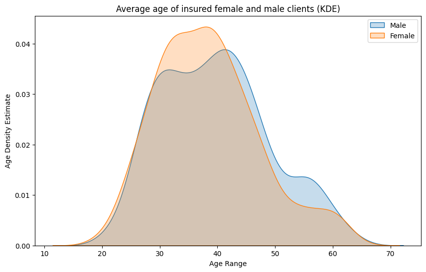

```python
plt.figure(figsize=(10, 6))

sns.kdeplot(data=df[df['insured_sex'] == 'MALE']['age'], label='Male', fill=True)
sns.kdeplot(data=df[df['insured_sex'] == 'FEMALE']['age'], label='Female', fill=True)


plt.xlabel('Age Range')
plt.ylabel('Age Density Estimate')
plt.title('Average age of insured female and male clients (KDE)')
plt.legend()

plt.show()
```

Figure 1 : A KDE to show the age density according to age and gender.

There is a slight trend in the insured client pool implying that insured females are on average younger that the insured male. Most insured clients fall in the age range of 25 to 45 years of age.

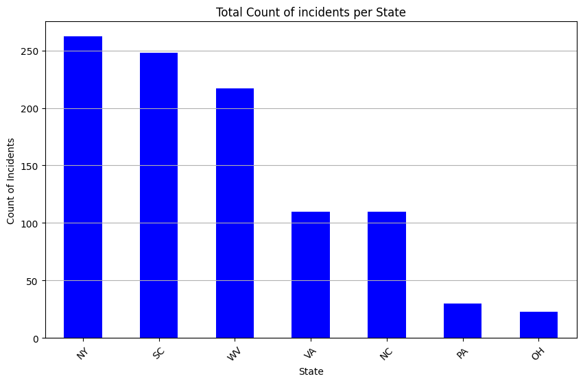

```python
state_counts = df['incident_state'].value_counts()


plt.figure(figsize=(10, 6))
state_counts.plot(kind='bar', color='blue')
plt.title('Total Count of incidents per State')
plt.xlabel('State')
plt.ylabel('Count of Incidents')
plt.xticks(rotation=45)
plt.grid(axis='y')

plt.show()
```

Figure 2: A bar chart showing the counts of incidents per state.

The trends seen here shows a general decrease from left to right showing New York has the highest rate of incidents at 260 and Ohio having the least at 25.

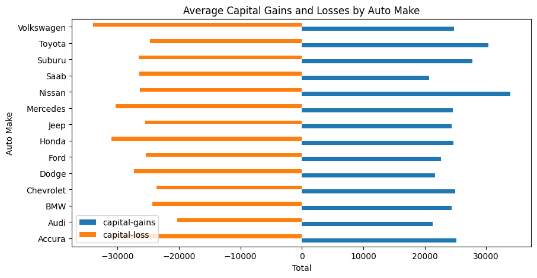

```python
grouped_data = df.groupby('auto_make')[['capital-gains', 'capital-loss']].mean()


fig, ax = plt.subplots(figsize=(10, 5))

grouped_data.plot(kind='barh', ax=ax)
ax.set_xlabel('Total')
ax.set_ylabel('Auto Make')
ax.set_title('Average Capital Gains and Losses by Auto Make')

plt.show()
```

Figure 3: Inverse bar chart showing the average capital gains and losses by automake

Figure 3 shows how profitable each car brand is to the insurance company. Volkswagon has a higher capital losss than gain demonstrating a poor profit auto make where as Nissan has a greater capital gain than loss.

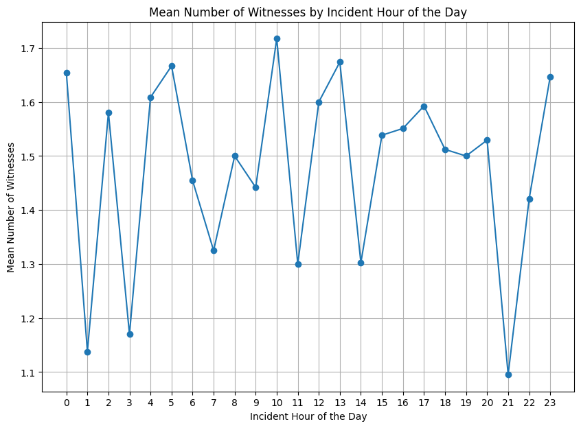

```python
mean_witnesses = df.groupby('incident_hour_of_the_day')['witnesses'].mean()

fig = plt.figure(figsize=(10, 7))
plt.plot(mean_witnesses.index, mean_witnesses.values, marker='o', linestyle='-')
plt.xlabel('Incident Hour of the Day')
plt.ylabel('Mean Number of Witnesses')
plt.title('Mean Number of Witnesses by Incident Hour of the Day')

plt.xticks(np.arange(0, 24, step=1), labels=np.arange(0, 24, step=1))  # Set x-axis ticks for each hour
plt.grid(True)
plt.show()
```

Figure 4: Line graph showing the likelihood of finding a witness per hour of the day.

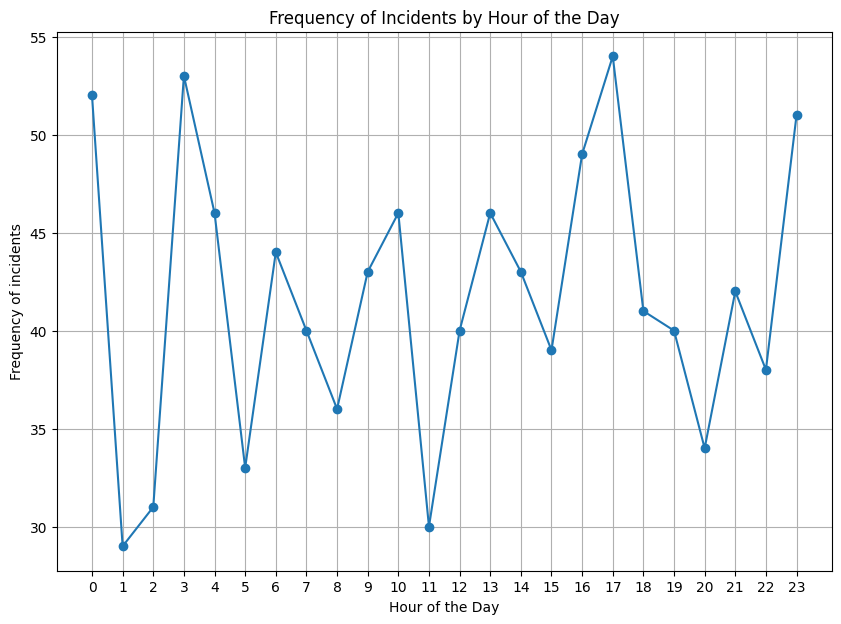

```python
mean_incidents = df['incident_hour_of_the_day'].value_counts().sort_index()

fig = plt.figure(figsize=(10, 7))
plt.plot(mean_incidents, marker='o', linestyle='-')
plt.xlabel('Hour of the Day')
plt.ylabel('Frequency of incidents')
plt.title('Frequency of Incidents by Hour of the Day')

plt.xticks(np.arange(0, 24, step=1), labels=np.arange(0, 24, step=1))
plt.grid(True)
plt.show()
```

Figure 5: Line graph showing the likelihood of an incident occuring per hour of the day.

There is a peak at 5pm depite a low average of incidents during daylight hours.

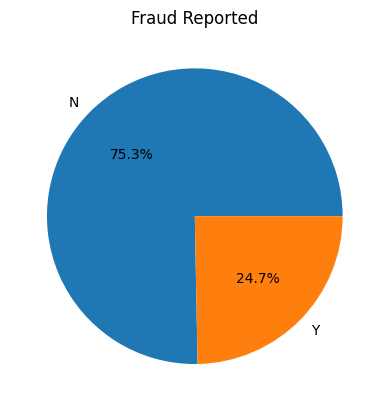

```python
grouped_claims = df['fraud_reported'].value_counts()

plt.pie(grouped_claims, labels=grouped_claims.index, autopct='%1.1f%%')
plt.title('Fraud Reported')
plt.show()
```

Figure 6: A pie chart showing the ratio of fraudulant and unfraudulant claims.

Relative to predicted trends, there is a high number of fraudulant cases.

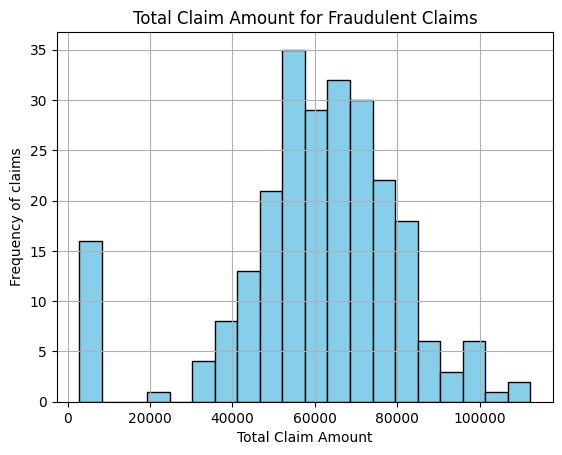

```python
fraudulent_claims = df[df['fraud_reported'] == 'Y']['total_claim_amount']

plt.hist(fraudulent_claims, bins=20, color='skyblue', edgecolor='black')
plt.xlabel('Total Claim Amount')
plt.ylabel('Frequency of claims')
plt.title('Total Claim Amount for Fraudulent Claims')
plt.grid(True)
plt.show()
```

Figure 7: Histogram showing the total claim amount where fraud is reported.

The general trend observed is that most fraudulent claims fall at about the 60,000 mark with a secondary notable peak below 10,000.

### Section 3a: Report Based Evaluations and Insights

Age and Gender

The age range and gender of insured clients could be of importance when considering the most profitable profile group to market a premium or insurance product towards. As seen in figure 1 the most populous age range currently insured is between the ages of 25 and 45. For this reason, marketing strategies would be most successful if targeted towards individuals within this age bracket, however to expand the current client base separate marketing strategies could be implemented to attract both younger and older clients.

Geographical

Further considerations into commuting habits of insured clients should be made prior to issuing a premium policy. As seen in figure 2, the highest amount of incidents occur in New York, South Carolina and West Virginia, therefore this should increase the premium pricing of clients frequenting these states.

Auto Make

Witnesses and time of day

In regards to figure 4, it may be assumed that an incident would present fewer witnesses during night and early morning hours. There is however no remarked trend in the data supporting this assumption. Although there is a visually noticable trough at 9pm, there is no supporting evidence to suggest that this is due to being at an advanced hour of the day. Given that the data set is relatively small and therefore presents many limitations when considering trends, an expanded view of incident records may improve predicted trends and aid evaluation of insurance fraud claims. Figure 5 supports a very similar conclusion that hour of the day does not predict the likelihood of incidence occurance. Similarly with expanded records this could help determine premium pricing.

Fraud Reported

Figure 6 demonstrates the incidence of recorded fraud within the data set. The limitation of this is that our data may represent a select group of records where fraud was initially suspected and sent for further investigation. When fraud is confirmed, total claim amount tends to fall at about 60,000 dollars. However it can also be noted that many fraudulant claims are also predictable a the lower end of 10,000 dollars meaning that smaller amount claims should be highly monitored.

### Section 3b: Dashboard Based Evaluations and Insights

Vehicle Insurance Claims Fraud

Insured Client Profiles

Geographical mapping of Incidents

The dashboard allows for further geographical exploration of the data namely allowing for a comparitive investigation of the state where the policy was issued and the state of incidence. This is of particular importance when noting that the incidence of a collision occuring in the state where the policy was taken is extremly low. In fact of the three states where a policy was issued: Ohio, Illinois and Indiana, the only state also representing state of incident was Ohio. Furthermore of the 1000 incidents recorded only 23 were in the state of Ohio. The dashboard also allows the user to track a client by their policy number such that the previously describe profiles can be further monitored in regards to their driving activities. Type of collision and witnesses at the scene are also data points that can be explored.

### Section 5: Conclusion

Given that data set only contains accidents, this justifies why total claim amount is significantly larger than total premium annual policy. If these dashboards were used in conjunction with real insurance data it would be possible to predict the profit for the insurance company by considering total premium annual policy over total claim amount.

Our system aims to help with identification of fraudulent cases, so far there are many fraudulent cases that are apparently unjustified. In the example of policy number 594783 for example, the total months as a customer is recorded as being 119, as such it raises the question as to why a client would pay for insurance for 10 years before filing a fraudulent claim. In addition, 1 witness is provided in the entered record.

In conclusion while no definite trends are observed, a typical fraudulent profile can be outlined: